**Hi, I'm Denis**

This notebook is quite large, but structured. I hope you have the Table Of Contents jupyter extension for better navigation or are using Jupyter Lab like me :)

All needed packages are listed in `requirements.txt`

# Travel case study

## Data

- clicks.csv Contains the daily number of aggregated clickouts in a hypothetical market. Table schema: date_ymd, click_count. To be used in tasks 1 and 2.
- hotel_details.csv Contains the following properties of a sample of hotels: hotel_id, city, country, stars, hotel_rating. All the hotels are in one of the following cities: Hanoi, Los Angeles, Miami, New York, Rio de Janeiro, and Stockholm. To be used in tasks 1, 3, and 4.
- hotel_metrics.csv Contains a number of daily metrics (date_ymd, hotel_id, impression_count, click_count, booking_count, avg_cpc, avg_clicked_price, avg_length_of_stay, avg_time_to_travel) of a list of accommodations. To be used in tasks 1, 3, and 4.

The columns on these datasets are defined as described below (some columns are present in more than one dataset):

- date_ymd: Date in the yyyymmdd format
- click_count: Number of clickouts made by users.
- hotel_id: Unique identifier of a given accommodation.
- city: City where the accommodation is located.
- country: Country where the accommodation is located.
- stars: Number of stars of the corresponding hotel.
- hotel_rating: Average rating given by users on the corresponding accommodation. The scale goes from 0 to 100.
- impression_count: Number of impressions of the corresponding accommodation.
- booking_count: Number of bookings made on the corresponding accommodation.
- avg_cpc: The average clicked CPC of the corresponding accommodation.
- avg_clicked_price: The average clicked price per night of the accommodation.
- avg_length_of_stay: The average clicked length of stay.
- avg_time_to_travel: The average clicked time to travel.

## Glossary

- advertiser: A booking platform. Some real-life examples of advertisers would be Expedia, Booking.com, Hotels.com, Trip.com, ...
- clickout: These are clicks made on specific hotel deals, leading the user to the landing page of the corresponding advertiser.
- impression: An impression is defined as the number of times the corresponding hotel appears in the result list of a given search.
- session: A session is defined as an active usage of the travel website for a continuous amount of time. One given session is contained on a single date.
- CPC: Cost per click. Each clickout the user performs has a CPC linked to it. The advertiser that receives the clickout pays the corresponding CPC value. The value of the CPC is defined by the advertiser in the form of a daily bid. For simplicity, you can assume that each hotel_id has a single CPC placed by each advertiser on a given day.
- Length of stay: Number of nights between check-in and check-out date.
- Time to travel: Number of days between the clickout and the check-in dates.

# Tasks

```python
RANDOM_SEED = 1337  # to reproduce operations with randomization
```

```python
import copy
import os

from collections import defaultdict, Counter
from datetime import timedelta
from functools import partial
from itertools import cycle
from time import time
from typing import List, Dict, Optional, Iterable

import matplotlib.pyplot as plt
import numpy as np
import pmdarima as pm
import pandas as pd
import seaborn as sns

from catboost import Pool, CatBoostClassifier

from matplotlib.figure import Figure

from pmdarima.arima import auto_arima
from pmdarima.arima.arima import ARIMA
from pmdarima.arima.utils import nsdiffs
from pmdarima.metrics import smape

from sklearn.ensemble import RandomForestClassifier
from sklearn.neighbors import KNeighborsClassifier
from sklearn.svm import SVC

from sklearn.metrics import mean_squared_error, make_scorer, f1_score, accuracy_score, balanced_accuracy_score, ConfusionMatrixDisplay
from sklearn.model_selection import train_test_split, RandomizedSearchCV, GridSearchCV, cross_val_score, cross_validate, StratifiedKFold
from sklearn.preprocessing import LabelEncoder, scale

from scipy.stats import boxcox, probplot
from scipy.special import inv_boxcox

from tqdm.notebook import tqdm
```

## Familiarizing with data

Since it is the first time you are seeing these data, take some time to get familiar with it. You can use this space to share with us any interesting findings you identified (data property, anomalies, trends, data quality issues, …)

### Read data

```python
DATA_FOLDER = 'data'
```

```python
clicks = pd.read_csv(os.path.join(DATA_FOLDER, 'clicks.csv'), parse_dates=['date_ymd'])
hotel_details = pd.read_csv(os.path.join(DATA_FOLDER, 'hotel_details.csv'))
hotel_metrics = pd.read_csv(os.path.join(DATA_FOLDER, 'hotel_metrics.csv'), parse_dates=['date_ymd'])
```

```python
hotel_metrics.head()
```

|  | date_ymd | hotel_id | impression_count | click_count | booking_count | avg_cpc | avg_clicked_price | avg_length_of_stay | avg_time_to_travel |
| --- | --- | --- | --- | --- | --- | --- | --- | --- | --- |
| 0 | 2019-08-02 | 7940 | 1931 | 16 | 0 | 0.93 | 168.87 | 1.63 | 23.25 |
| 1 | 2019-08-10 | 7940 | 931 | 27 | 0 | 1.46 | 157.94 | 1.70 | 22.22 |
| 2 | 2019-08-01 | 7940 | 1254 | 27 | 1 | 1.15 | 194.48 | 1.78 | 18.52 |
| 3 | 2019-08-07 | 7940 | 1614 | 36 | 0 | 1.19 | 170.31 | 2.06 | 23.50 |
| 4 | 2019-08-06 | 7940 | 1748 | 27 | 0 | 1.26 | 170.61 | 1.70 | 21.00 |

```python
hotel_details.head()
```

|  | hotel_id | city | country | stars | hotel_rating |
| --- | --- | --- | --- | --- | --- |
| 0 | 3202221 | Rio de Janeiro | Brazil | 0 | \N |
| 1 | 3826522 | Hanoi | Vietnam | 0 | 88.8 |
| 2 | 5433480 | Rio de Janeiro | Brazil | 0 | 81.66 |
| 3 | 6100572 | Miami | USA | 4 | 84.93 |
| 4 | 41209 | Stockholm | Sweden | 4 | 81.93 |

```python
clicks.head()
```

|  | date_ymd | click_count |
| --- | --- | --- |
| 0 | 2019-01-01 | 19712 |
| 1 | 2019-01-02 | 22632 |
| 2 | 2019-01-03 | 22579 |
| 3 | 2019-01-04 | 20716 |
| 4 | 2019-01-05 | 21953 |

### Closer look at hotel data

Let's look closely at hotel metrics

```python
hotel_metrics.describe()
```

|  | hotel_id | impression_count | click_count | booking_count | avg_cpc | avg_clicked_price | avg_length_of_stay | avg_time_to_travel |
| --- | --- | --- | --- | --- | --- | --- | --- | --- |
| count | 9.720000e+03 | 9720.000000 | 9720.000000 | 9720.000000 | 9720.000000 | 9720.000000 | 9720.000000 | 9720.000000 |
| mean | 1.943539e+06 | 850.007716 | 13.836523 | 0.142901 | 1.138248 | 175.266141 | 2.835045 | 41.855006 |
| std | 2.456578e+06 | 2167.276711 | 27.205402 | 0.509455 | 0.506972 | 148.288003 | 3.037070 | 42.112429 |
| min | 7.922000e+03 | 0.000000 | 1.000000 | 0.000000 | 0.010000 | 5.830000 | 1.000000 | -56.000000 |
| 25% | 5.917800e+04 | 46.000000 | 2.000000 | 0.000000 | 0.790000 | 99.442500 | 1.750000 | 15.407500 |
| 50% | 1.082852e+06 | 205.000000 | 6.000000 | 0.000000 | 1.135000 | 152.755000 | 2.345000 | 31.000000 |
| 75% | 3.145742e+06 | 730.000000 | 14.000000 | 0.000000 | 1.480000 | 213.462500 | 3.130000 | 54.000000 |
| max | 1.353717e+07 | 35408.000000 | 524.000000 | 8.000000 | 3.080000 | 4850.570000 | 206.000000 | 392.000000 |

```python
interesting_cols = ['impression_count', 'click_count', 'booking_count', 'avg_clicked_price', 'avg_length_of_stay', 'avg_time_to_travel']
```

We see here some possible outliers, e.g. 30k+ impression_count, 500+ clicks count, time to travel below zero (it would be actually nice). Also we should look at high prices and large time to travel. Such examples might be caused by incorrect logging or very rare user behavior. In any case, we should study it and most probably remove from data.

Update: upon closer look, I realized that there are hotel_ids from test among outliers, and some of them even have only 1 row in data... That is partially why I decided to clip on percentile instead of removing.

```
To output multiple subplots, the figure containing the passed axes is being cleared.
```

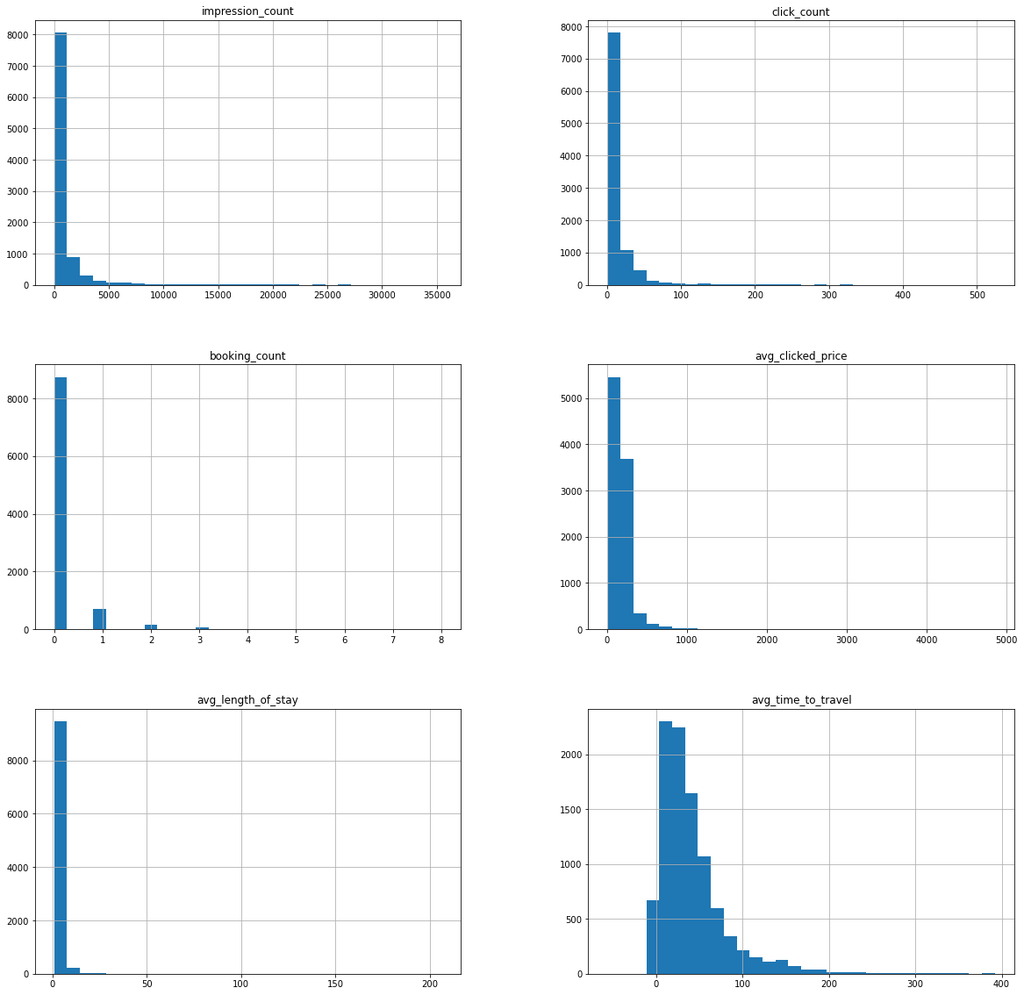

```python
fig, ax = plt.subplots(1, 1, figsize=(20, 20))

hotel_metrics[interesting_cols].hist(ax=ax, bins=30)

fig.show()
```

**Removing (clipping) outliers**

```python
def remove_outliers(feature: pd.Series, lower_perc: int=1, upper_perc: int=98) -> list:
    lower_bound, upper_bound = np.percentile(feature.values, [lower_perc, upper_perc])
    return np.clip(feature, lower_bound, upper_bound)

for col in interesting_cols:
    hotel_metrics[col] = remove_outliers(hotel_metrics[col])
```

Check what will change

```
To output multiple subplots, the figure containing the passed axes is being cleared.
```

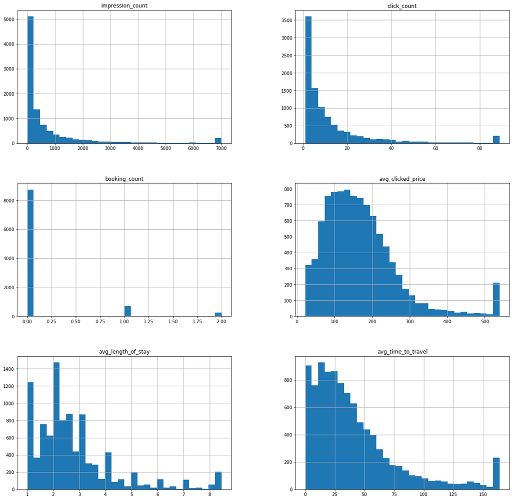

```python
fig, ax = plt.subplots(1, 1, figsize=(20, 20))

hotel_metrics[interesting_cols].hist(ax=ax, bins=30)

fig.show()
```

Seems better

```python
hotel_metrics[interesting_cols].describe()
```

|  | impression_count | click_count | booking_count | avg_clicked_price | avg_length_of_stay | avg_time_to_travel |
| --- | --- | --- | --- | --- | --- | --- |
| count | 9720.000000 | 9720.000000 | 9720.000000 | 9720.000000 | 9720.000000 | 9720.000000 |
| mean | 730.913621 | 12.345885 | 0.127366 | 169.100521 | 2.718133 | 40.597603 |
| std | 1351.567201 | 17.356254 | 0.406289 | 99.369872 | 1.563362 | 36.107122 |
| min | 1.000000 | 1.000000 | 0.000000 | 21.665200 | 1.000000 | 0.000000 |
| 25% | 46.000000 | 2.000000 | 0.000000 | 99.442500 | 1.750000 | 15.407500 |
| 50% | 205.000000 | 6.000000 | 0.000000 | 152.755000 | 2.345000 | 31.000000 |
| 75% | 730.000000 | 14.000000 | 0.000000 | 213.462500 | 3.130000 | 54.000000 |
| max | 7009.920000 | 89.000000 | 2.000000 | 538.908200 | 8.462000 | 164.000000 |

Let's add day of week. Maybe there is some interesing correlation with number of users' actions

```python
hotel_metrics['day_of_week'] = hotel_metrics['date_ymd'].dt.dayofweek
```

```python
hotel_metrics.groupby(by=['day_of_week'])[interesting_cols].agg(['count', 'mean', 'median'])
```

| day_of_week | impression_count count | impression_count mean | impression_count median | click_count count | click_count mean | click_count median | booking_count count | booking_count mean | booking_count median | avg_clicked_price count | avg_clicked_price mean | avg_clicked_price median | avg_length_of_stay count | avg_length_of_stay mean | avg_length_of_stay median | avg_time_to_travel count | avg_time_to_travel mean | avg_time_to_travel median |
| --- | --- | --- | --- | --- | --- | --- | --- | --- | --- | --- | --- | --- | --- | --- | --- | --- | --- | --- |
| 0 | 973 | 754.409209 | 226.0 | 973 | 12.619733 | 6.0 | 973 | 0.129496 | 0.0 | 973 | 172.096574 | 157.710 | 973 | 2.706989 | 2.35 | 973 | 43.779507 | 34.17 |
| 1 | 977 | 803.876725 | 236.0 | 977 | 13.289662 | 6.0 | 977 | 0.142272 | 0.0 | 977 | 171.371402 | 151.990 | 977 | 2.751245 | 2.40 | 977 | 38.782170 | 29.58 |
| 2 | 984 | 814.438862 | 192.0 | 984 | 12.959350 | 6.0 | 984 | 0.131098 | 0.0 | 984 | 167.572222 | 149.655 | 984 | 2.834732 | 2.44 | 984 | 43.811565 | 34.00 |
| 3 | 1972 | 757.263043 | 212.5 | 1972 | 12.546146 | 6.0 | 1972 | 0.134888 | 0.0 | 1972 | 167.319072 | 152.415 | 1972 | 2.814077 | 2.41 | 1972 | 41.953306 | 31.96 |
| 4 | 1938 | 721.496883 | 205.5 | 1938 | 12.428793 | 6.0 | 1938 | 0.123839 | 0.0 | 1938 | 168.099731 | 153.215 | 1938 | 2.633892 | 2.29 | 1938 | 38.002250 | 28.82 |
| 5 | 1881 | 676.801318 | 205.0 | 1881 | 11.784689 | 6.0 | 1881 | 0.119617 | 0.0 | 1881 | 170.586988 | 153.830 | 1881 | 2.614052 | 2.25 | 1881 | 38.342600 | 28.78 |
| 6 | 995 | 622.108422 | 170.0 | 995 | 11.047236 | 5.0 | 995 | 0.113568 | 0.0 | 995 | 168.122172 | 149.330 | 995 | 2.751893 | 2.40 | 995 | 42.721377 | 32.50 |

Number of impressions and clicks seems to be slightly lower at the end of the week

**Correlations**

Let's look at correlations between features

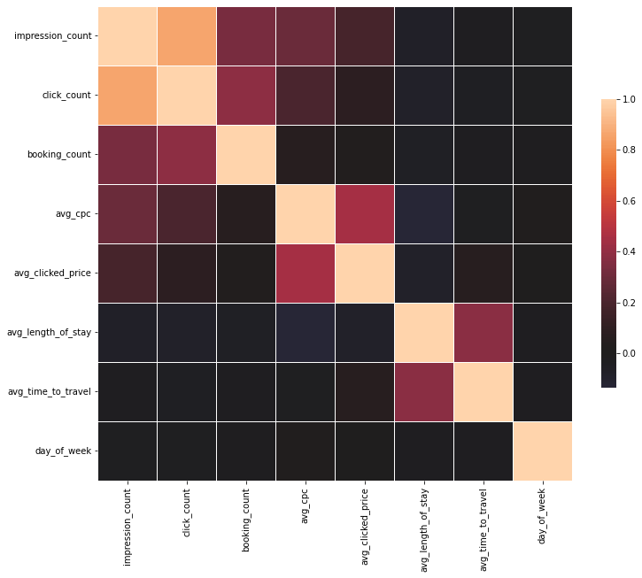

```python
correlations = hotel_metrics.drop(columns=['hotel_id']).corr()

fig, ax = plt.subplots(figsize=(12, 12))

sns.heatmap(correlations, center=0, square=True, linewidths=.5, cbar_kws={"shrink": .5})
```

```python
hotel_metrics.drop(columns=['day_of_week'], inplace=True)
```

### Add countries

Here we have categorical features, except for rating

```python
hotel_details.head()
```

|  | hotel_id | city | country | stars | hotel_rating |
| --- | --- | --- | --- | --- | --- |
| 0 | 3202221 | Rio de Janeiro | Brazil | 0 | \N |
| 1 | 3826522 | Hanoi | Vietnam | 0 | 88.8 |
| 2 | 5433480 | Rio de Janeiro | Brazil | 0 | 81.66 |
| 3 | 6100572 | Miami | USA | 4 | 84.93 |
| 4 | 41209 | Stockholm | Sweden | 4 | 81.93 |

```python
hotel_details['country'].value_counts()
```

```
USA        812
Brazil     258
unknown    162
Vietnam    148
Sweden     144
Name: country, dtype: int64
```

```python
hotel_details['city'].value_counts()
```

```
New York          473
Rio de Janeiro    258
Los Angeles       192
unknown           162
Hanoi             148
Miami             146
Stockholm         145
Name: city, dtype: int64
```

There is some class imbalance here with dominant New York class and second dominant Rio. In future we would need to deal with it

```python
hotel_details['stars'].value_counts()
```

```
3    455
4    406
0    345
2    190
5    105
1     23
Name: stars, dtype: int64
```

```python
hotel_details[hotel_details['stars'] == 0]['country'].value_counts()
```

```
USA        175
Brazil      84
unknown     31
Sweden      29
Vietnam     26
Name: country, dtype: int64
```

```python
hotel_details['hotel_rating'].head()
```

```
0       \N
1     88.8
2    81.66
3    84.93
4    81.93
Name: hotel_rating, dtype: object
```

There are apparently some missed values for rating. See how many

```python
missed_rating_char = hotel_details['hotel_rating'].iloc[0]
missed_rating_char
```

```
'\\N'
```

```python
f'{len(hotel_details[hotel_details["hotel_rating"] == missed_rating_char]) / len(hotel_details) * 100:.2f}% of data is missing rating'
```

```
'9.45% of data is missing rating'
```

```python
hotel_details[hotel_details['hotel_rating'] == missed_rating_char]['stars'].value_counts()
```

```
0    112
4     12
2      9
1      5
3      5
5      1
Name: stars, dtype: int64
```

```python
hotel_details[hotel_details['hotel_rating'] == missed_rating_char]['country'].value_counts()
```

```
USA        75
Brazil     41
unknown    17
Vietnam    10
Sweden      1
Name: country, dtype: int64
```

I guess, these values along with zero stars might correspond with relatively new hotels, which hasn't got enough data on a booking service yet. We also have target location variables here, so we cannot simply drop them. Thus, we should change them to something. For example, to the sample mean of hotels' ratings with similar stars count.

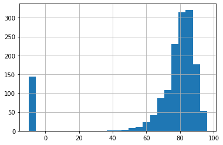

```python
hotel_details.replace(missed_rating_char, -10, inplace=True)
hotel_details['hotel_rating'] = hotel_details['hotel_rating'].astype('float')

hotel_details['hotel_rating'].hist(bins=25)
```

```python
stars_ratings = hotel_details[hotel_details['hotel_rating'] >= 0].groupby(by=['stars'], as_index=False)['hotel_rating'].agg(['count', 'min', 'max', 'median', 'mean'])
stars_ratings
```

| stars | count | min | max | median | mean |
| --- | --- | --- | --- | --- | --- |
| 0 | 233 | 46.07 | 96.11 | 80.840 | 79.548155 |
| 1 | 18 | 37.99 | 87.63 | 65.220 | 65.933889 |
| 2 | 181 | 44.88 | 94.39 | 73.460 | 73.072983 |
| 3 | 450 | 50.30 | 96.10 | 81.305 | 80.255622 |
| 4 | 394 | 55.74 | 95.61 | 83.420 | 82.826066 |
| 5 | 104 | 69.81 | 95.04 | 87.635 | 87.303942 |

```python
stars2missing_rating = stars_ratings['mean'].to_dict()
hotel_details.loc[hotel_details['hotel_rating'] < 0, ['hotel_rating']] = hotel_details[hotel_details['hotel_rating'] < 0]['stars'].apply(lambda star: stars2missing_rating[star])
```

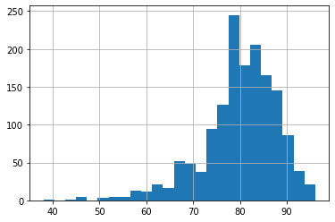

```python
hotel_details.hotel_rating.hist(bins=25)
```

Merge into one table

```python
united_hotel_metrics = pd.merge(hotel_metrics, hotel_details, how='left', on='hotel_id')
united_hotel_metrics.head()
```

|  | date_ymd | hotel_id | impression_count | click_count | booking_count | avg_cpc | avg_clicked_price | avg_length_of_stay | avg_time_to_travel | city | country | stars | hotel_rating |
| --- | --- | --- | --- | --- | --- | --- | --- | --- | --- | --- | --- | --- | --- |
| 0 | 2019-08-02 | 7940 | 1931.0 | 16.0 | 0.0 | 0.93 | 168.87 | 1.63 | 23.25 | Los Angeles | USA | 2 | 74.17 |
| 1 | 2019-08-10 | 7940 | 931.0 | 27.0 | 0.0 | 1.46 | 157.94 | 1.70 | 22.22 | Los Angeles | USA | 2 | 74.17 |
| 2 | 2019-08-01 | 7940 | 1254.0 | 27.0 | 1.0 | 1.15 | 194.48 | 1.78 | 18.52 | Los Angeles | USA | 2 | 74.17 |
| 3 | 2019-08-07 | 7940 | 1614.0 | 36.0 | 0.0 | 1.19 | 170.31 | 2.06 | 23.50 | Los Angeles | USA | 2 | 74.17 |
| 4 | 2019-08-06 | 7940 | 1748.0 | 27.0 | 0.0 | 1.26 | 170.61 | 1.70 | 21.00 | Los Angeles | USA | 2 | 74.17 |

```python
united_hotel_metrics['country'].value_counts()
```

```
USA        6911
unknown    1116
Brazil      837
Sweden      560
Vietnam     296
Name: country, dtype: int64
```

```python
united_hotel_metrics['city'].value_counts()
```

```
New York          4247
Los Angeles       1440
Miami             1222
unknown           1116
Rio de Janeiro     837
Stockholm          562
Hanoi              296
Name: city, dtype: int64
```

### Clicks

Let's look at the clicks time plot

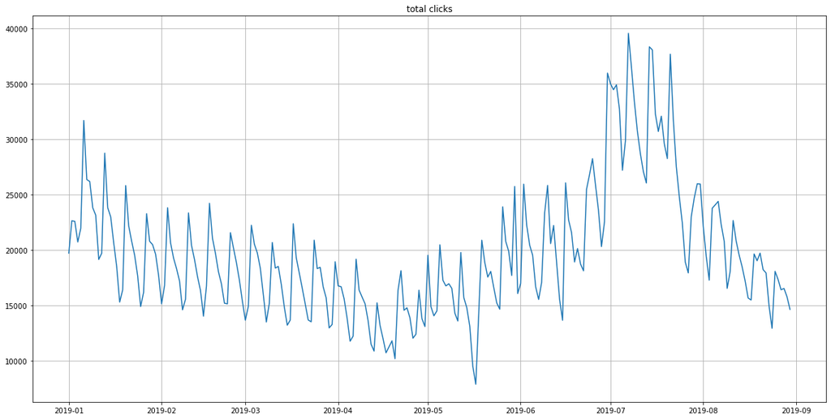

```python
fig, ax = plt.subplots(1, 1, figsize=(20, 10))

ax.plot(clicks['date_ymd'], clicks['click_count'])
ax.grid()
ax.set_title('total clicks')
fig.show()
```

We can suppose there exists at least a weekly period. We also see 3 trends here:

1. Decreasing from Jan to mid April
2. Increasing from mid April to peak values in July
3. Decreasing from July upwards

There is a sudden drop in the middle of May. It might be a natural anomaly, e.g. caused by some holidays or special events.

Higher values in July are a little strange. If I were analyzing such data, I would certainly look at previous years' graph and compare. For now, I will suppose, it is due to seasonality. A light Google search led me to [Eurostat data](https://ec.europa.eu/eurostat/statistics-explained/index.php?title=Seasonality_in_tourism_demand) that also supports this explanation.

Interesting to see, on which weekdays we have local peaks

```python
clicks['weekday'] = clicks['date_ymd'].dt.day_name()
```

```python
def plot_clicks_with_weekdays(clicks: pd.DataFrame, period: slice) -> Figure:

    clicks_slice = clicks[period]

    fig, ax = plt.subplots(1, 1, figsize=(12, 10))

    ax.plot(clicks_slice['date_ymd'], clicks_slice['click_count'])

    ax.set_xticks(clicks_slice['date_ymd'])
    joint_label = [f'{day} ({ts.day}/{ts.month})' for (ts, day) in clicks_slice[['date_ymd', 'weekday']].values]
    ax.set_xticklabels(joint_label, rotation=80)
    ax.grid()
    ax.set_title(f'Clicks from {clicks_slice["date_ymd"].iloc[0].date()} to {clicks_slice["date_ymd"].iloc[-1].date()}')

    return fig
```

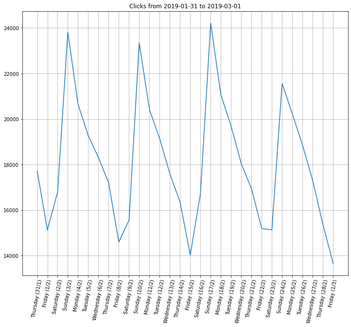

```python
feb_period = slice(30, 60)

fig = plot_clicks_with_weekdays(clicks, feb_period)
fig.show()
```

Interesting, that users peak searches are happening on Sundays :)

What about busy summer season?

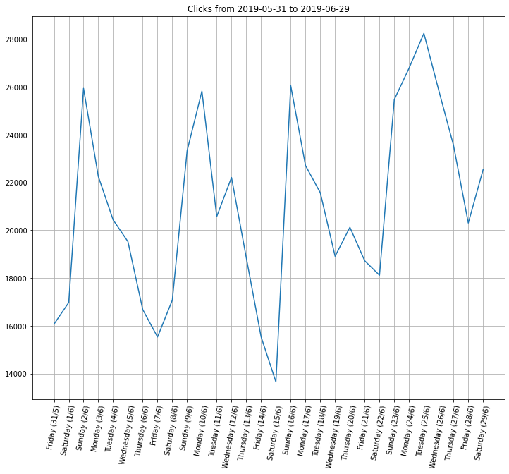

```python
june_period = slice(150, 180)

fig = plot_clicks_with_weekdays(clicks, june_period)
fig.show()
```

Generally this weekly clicks pattern is the same except for the end of June. Maybe there were some consequent holidays

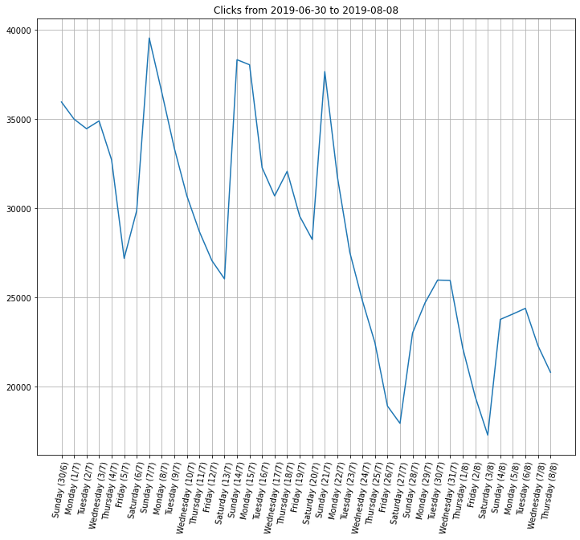

```python
july_period = slice(180, 220)

fig = plot_clicks_with_weekdays(clicks, july_period)
fig.show()
```

And it returns back in July

## Clicks Prediction

I would say, that we actually don't have enough data to predict correctly and be certain that out predictions are not completely off. As we saw in previous section, clicks data has its seasonal biases, thus it would be useful to see previous years autumn data. We could also use some additional information about special promotions and holidays, distribution of clicks by hotels' countries, etc.

Still, we will try to predict *something*

```python
clicks.set_index('date_ymd', inplace=True)
```

```python
COLORS = cycle(['b','g','r','c','m','y'])  # have different colors in complex plots across this notebook
```

At first, let's look at autocorrelation plot. From that we could guess parameters for seasonality.

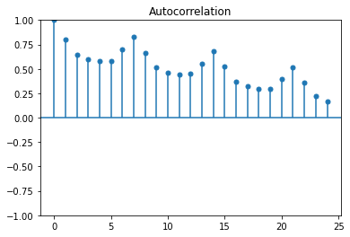

```python
pm.plot_acf(clicks['click_count'])
```

There are peaks for weekly intervals. We will use that in our models

### Scale transform

We might also benefit from a scale transformation

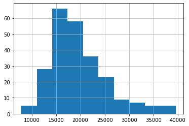

```python
clicks['click_count'].hist()
```

Looks like slightly skewed Normal

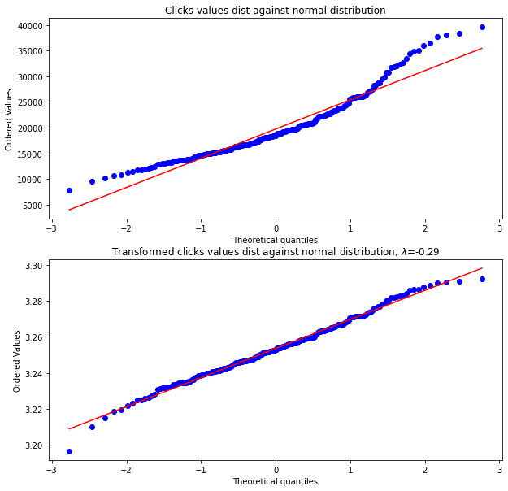

```python
fig, ax = plt.subplots(2, 1, figsize=(10, 10))

probplot(clicks['click_count'], plot=ax[0])
ax[0].set_title('Clicks values dist against normal distribution')

bc_clicks, lam = boxcox(clicks['click_count'])
probplot(bc_clicks, plot=ax[1])
ax[1].set_title(f'Transformed clicks values dist against normal distribution, $\lambda$={lam:.2f}')

fig.show()
```

Now we stabilized the variance.

Check that the inverse transformation works correctly

```python
assert np.allclose(clicks['click_count'], inv_boxcox(bc_clicks, lam))
```

```python
TARGET_COLUMN = 'bc_click_count'
LAMBDA = lam

clicks[TARGET_COLUMN] = bc_clicks
```

### Finding the right model

At first we will split the dataset into train, val and test groups. On this data we will do the following:

1. Find transformation to lower the variance of data
2. Fit models to train, find best parameters for (seasonal) ARIMA
3. Make daily predictions on val, add new data to models after each prediction
4. Make predictions for the remaining data, evaluate on gapped test
5. Choose best model, update it with all available data and make predictions for September

```python
val_offset = 14
test_gap = 3
test_offset = 14
train_offset = val_offset + test_offset + test_gap

train = clicks[TARGET_COLUMN][:-train_offset]
val = clicks[TARGET_COLUMN][-train_offset:-test_offset - test_gap]
test = clicks[TARGET_COLUMN][-test_offset:]
```

We will use AutoARIMA package, which essentially is an interface over statsmodels ARIMA and SARIMAX.

In the cell below we are defining ranges for optimal parameters search.

Although, we speculated above about the weekly seasonality in our data, we will also train one model with no seasonality.

```python
common_params = {
    "start_p": 0,
    "start_q": 0,
    "max_p": 7,
    "max_q": 4,
    "max_d": 4,
}

models_params = {
    0: {"seasonal" : False},
    7:  {"seasonal": True, "m": 7},
    14:  {"seasonal": True, "m": 14},
    21:  {"seasonal": True, "m": 21},
    28:  {"seasonal": True, "m": 28},
}
```

```python
models = []

for seasonality in tqdm(models_params):
    params = models_params[seasonality]
    params.update(common_params)
    model = pm.auto_arima(
        train,
        stepwise=False,
        approximation=False,
        error_action='ignore',
        **params
    )
    models.append(model)
```

For analyzing, we will choose two metrics: Mean Squared Error and Symmetric Mean Absolute Percentage Error.

```python
metrics = {
    'mse': mean_squared_error,
    'smape': smape,
}
```

```python
def forecast_one_step(model: ARIMA, alpha: float=0.05) -> tuple:
    '''
    Function from "Stock market prediction" example
    https://alkaline-ml.com/pmdarima/usecases/stocks.html#pre-modeling-analysis
    '''
    fc, conf_int = model.predict(n_periods=1, return_conf_int=True, alpha=alpha)
    return fc.tolist()[0], np.asarray(conf_int).tolist()[0]

def plot_arima_models(
    data: pd.Series,
    models: List[ARIMA],
    metrics: Dict['str', callable],
    update_model: bool= False,
    conf_alpha: float = 0.05,
    gap: int = 0,
    figsize:tuple=(12, 18),
) -> Figure:

    if gap and update_model:
        print('Due to using gap, model should not be updated with new data')
        update_model = False

    fig, axes = plt.subplots(len(models), 1, figsize=figsize)

    fig.suptitle('Data vs model predictions', fontsize=16)

    for i, model in enumerate(models):
        if update_model:
            model_fc = []
            model_ci = []
            for obs in data:
                fc, ci = forecast_one_step(model, alpha=conf_alpha)
                model_fc.append(fc)
                model_ci.append(ci)
                model.update(obs)

            model_ci = np.array(model_ci)
        else:
            model_fc, model_ci = model.predict(n_periods=len(data) + gap, return_conf_int=True, alpha=conf_alpha)

        model_fc = model_fc[gap:]
        model_ci = model_ci[gap:]

        axes[i].scatter(data.index, data, marker='x', label='real data')
        axes[i].set_xticks(data.index.tolist())
        axes[i].set_xticklabels([ts.date() for ts in data.index], rotation=15)

        metric_values = []
        for metric_name, metric in metrics.items():
            metric_values.append(f'{metric_name}={metric(data, model_fc):.4f}')

        color = next(COLORS)

        axes[i].plot(
            data.index,
            model_fc,
            label=f'preds ({", ".join(metric_values)})',
            color=color,
        )
        axes[i].fill_between(
            data.index,
            model_ci[:, 0],
            model_ci[:, 1],
            alpha=0.1,
            label=f'{(1-conf_alpha)*100:.2f}% CI',
            color=color
        )

        axes[i].set_title(f'{str(model)}')
        axes[i].legend()
        axes[i].grid()

    fig.tight_layout(rect=[0, 0.03, 1, 0.95])

    return fig
```

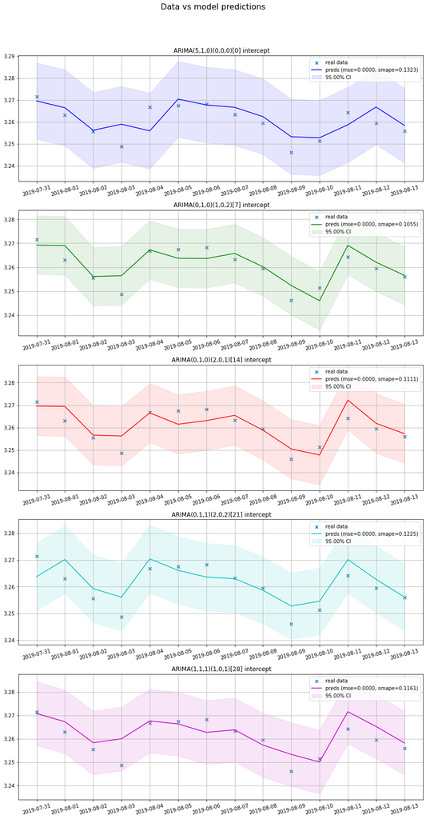

```python
figure = plot_arima_models(
    val,
    models,
    metrics,
    update_model=True,
    gap=0,
    figsize=(12, 24)
)
```

The performance is quite close within models with explicit seasonality.

For the version without seasonal features, we can see that the best *p* term is quite high, so as the model complexity. And the SMAPE is still worse.

Now I want to further analyze the candidates for the best predictive model. Basically, I want to check if the residuals are autocorrelated, and are they normally distributed

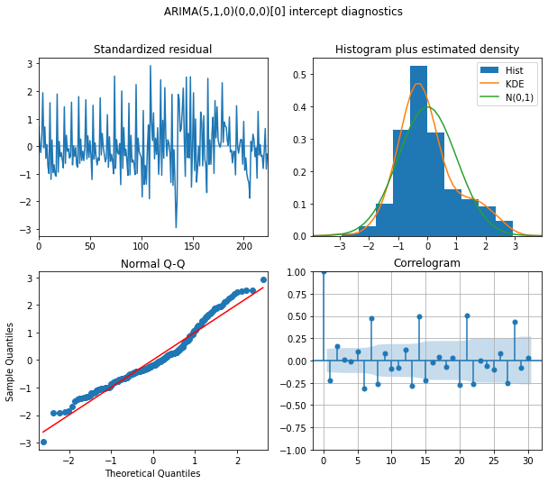

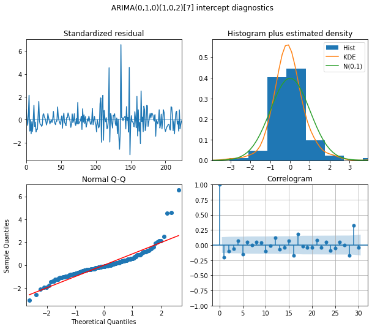

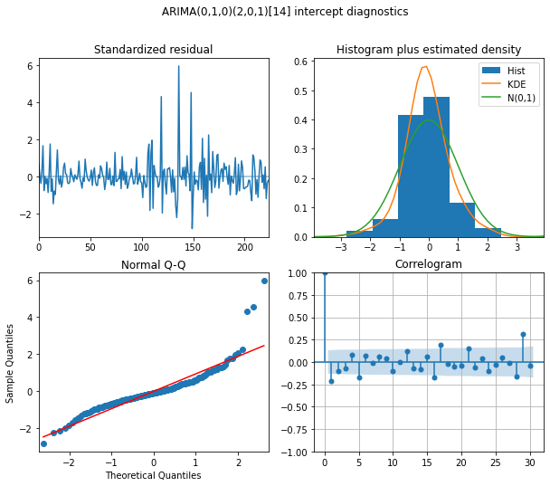

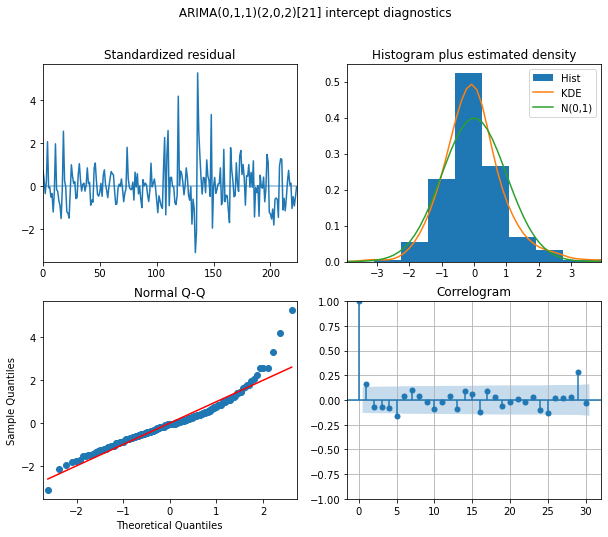

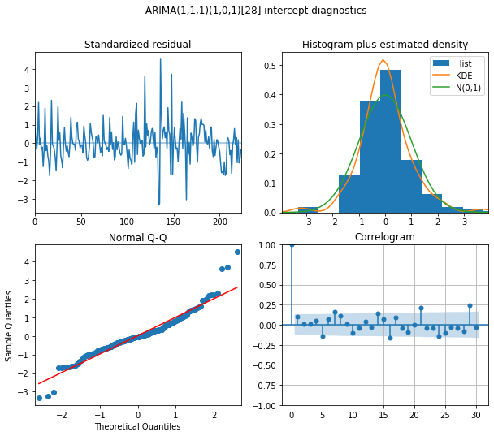

```python
for model in models:
    model.plot_diagnostics(figsize=(10, 8), lags=30)
    plt.suptitle(f'{str(model)} diagnostics')
    plt.grid()

plt.show()
```

Well, to be honest no model is perfect :)

Some observations:

- The model without seasonality is the worst here. Its correlogram suggests many unexplained dependencies and the residuals are more distant from Normal distribution than in other models;
- On ACF plots we see that there are some potentially unexplained patterns, as some significant autocorrelations are found;
- On the bottom left graphs we see deviations of residuals distributions from the red line in all of our models. But these deviations are smaller for seasonal ones;
- Residuals on seasonal models oscillate around zero, which is good. But there might be a small bias in predictions;
- Seems like the $4^{th}$ model, ARIMA (0, 1, 1)(2, 0, 2)[21] might be the best model here

The deviations can be explained with the high values in clicks specific to July. If given more data, we might construct a better model.

Evaluate on the gapped test set

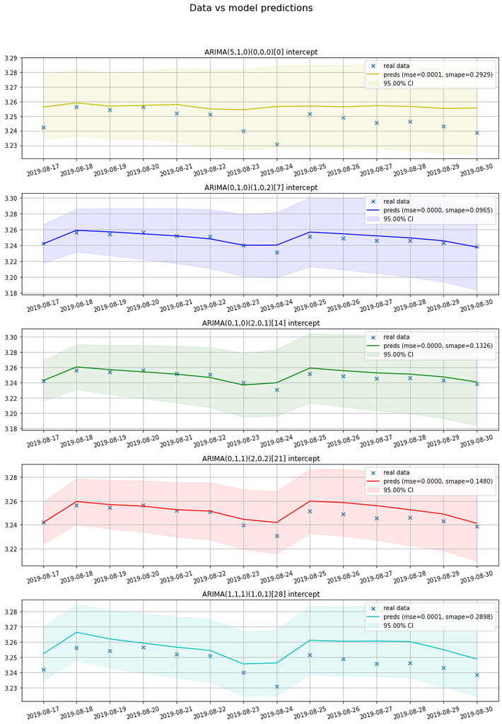

```python
figure = plot_arima_models(
    test,
    models,
    metrics,
    update_model=False,
    gap=test_gap,
)
```

So, as we previously decided, we will choose `ARIMA(0, 1, 1)(2, 0, 2)[21]` as the best.

### Predict for September

The last date in clicks is 30th August. So, we need to predict 31 days to cover all September

```python
n_days_to_predict = 31
test_dates = [clicks.index[-1] + timedelta(days=i) for i in range(1, n_days_to_predict + 1)]
```

```python
best_model = copy.deepcopy(models[3])

for obs in clicks[TARGET_COLUMN][-test_offset - test_gap:]:
    best_model.update(obs)

assert best_model.nobs_ == len(clicks)
```

```python
model_fc, model_ci = best_model.predict(n_periods=n_days_to_predict, return_conf_int=True, alpha=0.1)
```

If we ran a Box-Cox transfomation, we would need to scale back our predictions

```python
model_fc = inv_boxcox(model_fc, LAMBDA)
model_ci = inv_boxcox(model_ci, LAMBDA)
```

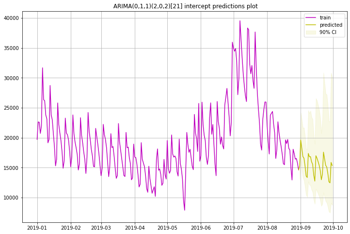

```python
fig, ax = plt.subplots(1, 1, figsize=(12,8))

train_color = next(COLORS)
test_color = next(COLORS)

# plot train data
ax.set_title(f'{str(best_model)} predictions plot')
ax.plot(clicks['click_count'], color=train_color, label='train')

# add last train value to dates and forecasts for uninterrupted graph
plot_dates = [clicks.index[-1]]
plot_dates.extend(test_dates)
plot_fc = [clicks['click_count'].iloc[-1]]
plot_fc.extend(model_fc.tolist())

# plot predictions
ax.plot(plot_dates, plot_fc, color=test_color, label='predicted')

# plot confidence intervals
ax.fill_between(
            test_dates,
            model_ci[:, 0],
            model_ci[:, 1],
            alpha=0.1,
            label=f'90% CI',
            color=test_color
        )
ax.grid()
ax.legend()

fig.show()
```

## Location Prediction

```python
united_hotel_metrics['city'].value_counts()
```

```
New York          4247
Los Angeles       1440
Miami             1222
unknown           1116
Rio de Janeiro     837
Stockholm          562
Hanoi              296
Name: city, dtype: int64
```

```python
hotel_details['city'].value_counts()
```

```
New York          473
Rio de Janeiro    258
Los Angeles       192
unknown           162
Hanoi             148
Miami             146
Stockholm         145
Name: city, dtype: int64
```

```python
united_hotel_metrics.head()
```

|  | date_ymd | hotel_id | impression_count | click_count | booking_count | avg_cpc | avg_clicked_price | avg_length_of_stay | avg_time_to_travel | city | country | stars | hotel_rating |
| --- | --- | --- | --- | --- | --- | --- | --- | --- | --- | --- | --- | --- | --- |
| 0 | 2019-08-02 | 7940 | 1931.0 | 16.0 | 0.0 | 0.93 | 168.87 | 1.63 | 23.25 | Los Angeles | USA | 2 | 74.17 |
| 1 | 2019-08-10 | 7940 | 931.0 | 27.0 | 0.0 | 1.46 | 157.94 | 1.70 | 22.22 | Los Angeles | USA | 2 | 74.17 |
| 2 | 2019-08-01 | 7940 | 1254.0 | 27.0 | 1.0 | 1.15 | 194.48 | 1.78 | 18.52 | Los Angeles | USA | 2 | 74.17 |
| 3 | 2019-08-07 | 7940 | 1614.0 | 36.0 | 0.0 | 1.19 | 170.31 | 2.06 | 23.50 | Los Angeles | USA | 2 | 74.17 |
| 4 | 2019-08-06 | 7940 | 1748.0 | 27.0 | 0.0 | 1.26 | 170.61 | 1.70 | 21.00 | Los Angeles | USA | 2 | 74.17 |

### Generate some features

At first, I wanted to calculate mean metrics values over the week for each hotel (impressions, clicks, bookings, cpc, clicked price, length of stay, time to travel) and use it as my dataset. But on the other hand, it would significantly shorten our dataset, about 8 times.

So I will use daily statistics as my train and test. And in the end, I will group my answer by hotel_id.

```python
feature_columns = ['impression_count', 'click_count', 'booking_count', 'avg_cpc', 'avg_clicked_price', 'avg_length_of_stay', 'avg_time_to_travel', 'hotel_rating', 'stars']
```

Let's calculate some common values such as mean of mentioned above metrics over all hotels + their values by city

```python
data_agg_metrics = united_hotel_metrics[united_hotel_metrics['city'] != 'unknown'][feature_columns].mean().to_frame()
data_agg_metrics
```

|  | 0 |
| --- | --- |
| impression_count | 746.330191 |
| click_count | 12.438633 |
| booking_count | 0.125291 |
| avg_cpc | 1.141626 |
| avg_clicked_price | 169.163715 |
| avg_length_of_stay | 2.715997 |
| avg_time_to_travel | 40.816692 |
| hotel_rating | 80.246568 |
| stars | 2.860762 |

```python
city_agg_metrics = united_hotel_metrics[united_hotel_metrics['city'] != 'unknown'].groupby(by=['city'], as_index=False)[feature_columns].mean()
city_agg_metrics
```

|  | city | impression_count | click_count | booking_count | avg_cpc | avg_clicked_price | avg_length_of_stay | avg_time_to_travel | hotel_rating | stars |
| --- | --- | --- | --- | --- | --- | --- | --- | --- | --- | --- |
| 0 | Hanoi | 11.104730 | 1.533784 | 0.010135 | 0.640912 | 71.052309 | 2.170804 | 37.437500 | 85.032464 | 3.381757 |
| 1 | Los Angeles | 580.836528 | 11.252778 | 0.136806 | 1.052812 | 154.120260 | 2.262685 | 27.145208 | 75.460372 | 2.246528 |
| 2 | Miami | 596.205401 | 12.119476 | 0.156301 | 0.946718 | 117.986825 | 2.729741 | 45.022300 | 78.952845 | 2.679214 |
| 3 | New York | 1131.856925 | 17.011773 | 0.149753 | 1.285757 | 214.978266 | 2.573072 | 39.415357 | 81.601287 | 3.003296 |
| 4 | Rio de Janeiro | 38.556750 | 2.583035 | 0.028674 | 0.777814 | 94.663983 | 4.355969 | 69.839200 | 80.962494 | 3.175627 |
| 5 | Stockholm | 24.736655 | 2.033808 | 0.048043 | 1.509359 | 135.397861 | 2.772391 | 35.847936 | 81.498716 | 3.008897 |

```python
cities = city_agg_metrics['city'].values

for feature in feature_columns:
        united_hotel_metrics[f'{feature}_all_ratio'] = united_hotel_metrics[feature] / data_agg_metrics.loc[feature].values[0]
        for city in cities:
            united_hotel_metrics[f'{feature}_{city.split()[0].lower()}_ratio'] = united_hotel_metrics[feature] / city_agg_metrics.loc[city_agg_metrics['city'] == city][feature].values[0]
```

```python
united_hotel_metrics.head()
```

|  | date_ymd | hotel_id | impression_count | click_count | booking_count | avg_cpc | avg_clicked_price | avg_length_of_stay | avg_time_to_travel | city | ... | hotel_rating_new_ratio | hotel_rating_rio_ratio | hotel_rating_stockholm_ratio | stars_all_ratio | stars_hanoi_ratio | stars_los_ratio | stars_miami_ratio | stars_new_ratio | stars_rio_ratio | stars_stockholm_ratio |
| --- | --- | --- | --- | --- | --- | --- | --- | --- | --- | --- | --- | --- | --- | --- | --- | --- | --- | --- | --- | --- | --- |
| 0 | 2019-08-02 | 7940 | 1931.0 | 16.0 | 0.0 | 0.93 | 168.87 | 1.63 | 23.25 | Los Angeles | ... | 0.908932 | 0.916103 | 0.910076 | 0.699114 | 0.591409 | 0.890263 | 0.746487 | 0.665935 | 0.629797 | 0.664695 |
| 1 | 2019-08-10 | 7940 | 931.0 | 27.0 | 0.0 | 1.46 | 157.94 | 1.70 | 22.22 | Los Angeles | ... | 0.908932 | 0.916103 | 0.910076 | 0.699114 | 0.591409 | 0.890263 | 0.746487 | 0.665935 | 0.629797 | 0.664695 |
| 2 | 2019-08-01 | 7940 | 1254.0 | 27.0 | 1.0 | 1.15 | 194.48 | 1.78 | 18.52 | Los Angeles | ... | 0.908932 | 0.916103 | 0.910076 | 0.699114 | 0.591409 | 0.890263 | 0.746487 | 0.665935 | 0.629797 | 0.664695 |
| 3 | 2019-08-07 | 7940 | 1614.0 | 36.0 | 0.0 | 1.19 | 170.31 | 2.06 | 23.50 | Los Angeles | ... | 0.908932 | 0.916103 | 0.910076 | 0.699114 | 0.591409 | 0.890263 | 0.746487 | 0.665935 | 0.629797 | 0.664695 |
| 4 | 2019-08-06 | 7940 | 1748.0 | 27.0 | 0.0 | 1.26 | 170.61 | 1.70 | 21.00 | Los Angeles | ... | 0.908932 | 0.916103 | 0.910076 | 0.699114 | 0.591409 | 0.890263 | 0.746487 | 0.665935 | 0.629797 | 0.664695 |

5 rows × 76 columns

```python
united_hotel_metrics.columns
```

```
Index(['date_ymd', 'hotel_id', 'impression_count', 'click_count',
       'booking_count', 'avg_cpc', 'avg_clicked_price', 'avg_length_of_stay',
       'avg_time_to_travel', 'city', 'country', 'stars', 'hotel_rating',
       'impression_count_all_ratio', 'impression_count_hanoi_ratio',
       'impression_count_los_ratio', 'impression_count_miami_ratio',
       'impression_count_new_ratio', 'impression_count_rio_ratio',
       'impression_count_stockholm_ratio', 'click_count_all_ratio',
       'click_count_hanoi_ratio', 'click_count_los_ratio',
       'click_count_miami_ratio', 'click_count_new_ratio',
       'click_count_rio_ratio', 'click_count_stockholm_ratio',
       'booking_count_all_ratio', 'booking_count_hanoi_ratio',
       'booking_count_los_ratio', 'booking_count_miami_ratio',
       'booking_count_new_ratio', 'booking_count_rio_ratio',
       'booking_count_stockholm_ratio', 'avg_cpc_all_ratio',
       'avg_cpc_hanoi_ratio', 'avg_cpc_los_ratio', 'avg_cpc_miami_ratio',
       'avg_cpc_new_ratio', 'avg_cpc_rio_ratio', 'avg_cpc_stockholm_ratio',
       'avg_clicked_price_all_ratio', 'avg_clicked_price_hanoi_ratio',
       'avg_clicked_price_los_ratio', 'avg_clicked_price_miami_ratio',
       'avg_clicked_price_new_ratio', 'avg_clicked_price_rio_ratio',
       'avg_clicked_price_stockholm_ratio', 'avg_length_of_stay_all_ratio',
       'avg_length_of_stay_hanoi_ratio', 'avg_length_of_stay_los_ratio',
       'avg_length_of_stay_miami_ratio', 'avg_length_of_stay_new_ratio',
       'avg_length_of_stay_rio_ratio', 'avg_length_of_stay_stockholm_ratio',
       'avg_time_to_travel_all_ratio', 'avg_time_to_travel_hanoi_ratio',
       'avg_time_to_travel_los_ratio', 'avg_time_to_travel_miami_ratio',
       'avg_time_to_travel_new_ratio', 'avg_time_to_travel_rio_ratio',
       'avg_time_to_travel_stockholm_ratio', 'hotel_rating_all_ratio',
       'hotel_rating_hanoi_ratio', 'hotel_rating_los_ratio',
       'hotel_rating_miami_ratio', 'hotel_rating_new_ratio',
       'hotel_rating_rio_ratio', 'hotel_rating_stockholm_ratio',
       'stars_all_ratio', 'stars_hanoi_ratio', 'stars_los_ratio',
       'stars_miami_ratio', 'stars_new_ratio', 'stars_rio_ratio',
       'stars_stockholm_ratio'],
      dtype='object')
```

Such extensive feature engineering might be unnecessary, but we will see. Nevertheless, we can possibly remove groups of correlated features if needed

Put it into a function

```python
def generate_features(
    hotel_metrics: pd.DataFrame,
    hotel_details: pd.DataFrame,
    feature_agg_columns: list
) -> pd.DataFrame:

    united_hotel_metrics = pd.merge(hotel_metrics, hotel_details, how='left', on='hotel_id')
    united_hotel_metrics.drop(columns=['date_ymd', 'country'], inplace=True)

    data_agg_metrics = united_hotel_metrics[united_hotel_metrics['city'] != 'unknown'][feature_agg_columns].mean().to_frame()
    city_agg_metrics = united_hotel_metrics[united_hotel_metrics['city'] != 'unknown'].groupby(by=['city'], as_index=False)[feature_agg_columns].mean()

    cities = city_agg_metrics['city'].values

    for feature in feature_agg_columns:
        united_hotel_metrics[f'{feature}_all_ratio'] = united_hotel_metrics[feature] / data_agg_metrics.loc[feature].values[0]
        for city in cities:
            united_hotel_metrics[f'{feature}_{city.split()[0].lower()}_ratio'] = united_hotel_metrics[feature] / city_agg_metrics.loc[city_agg_metrics['city'] == city][feature].values[0]

    return united_hotel_metrics
```

### Finding the right model

#### Splitting data

At first, we need to create our test set of hotels with `unknown` location

```python
hotel_agg_metrics = generate_features(hotel_metrics, hotel_details, feature_agg_columns=feature_columns)
```

```python
X_final_test = hotel_agg_metrics.loc[hotel_agg_metrics['city'] == 'unknown'].copy()
X_final_test.drop(columns=['city'], inplace=True)

hotel_agg_metrics.drop(columns=['hotel_id'], inplace=True)
```

```python
hotel_agg_metrics.drop(hotel_agg_metrics[hotel_agg_metrics['city'] == 'unknown'].index, inplace=True)
```

Target is our labels encoded to numbers

```python
target = hotel_agg_metrics['city'].copy()

le = LabelEncoder()
le.fit(target.unique())
target = le.transform(target)

hotel_agg_metrics.drop(columns=['city'], inplace=True)
```

Creating train and test splits to estimate performance of model candidates

```python
X_data = hotel_agg_metrics.copy()
X_train, X_val, y_train, y_val = train_test_split(X_data, target, train_size=0.8, random_state=RANDOM_SEED)
```

It is a good practice to scale the features. It would benefit models, which find linear dependencies, e.g. Support Vector Machines.

```python
X_train = scale(X_train)
X_val = scale(X_val)
```

#### Initial models estimate

We will estimate model performances on train features set using k-fold cross-validation. At first, we will guess the parameters and later search for the most optimal ones.

As we have a class disbalance here, we must include some kind of weighting to our metrics. Otherwise scores like `accuracy` will not be much informative. Indeed, we will have about 50% accuracy just by predicting the major class, if we do not do any adjustments

```python
def get_name(clf) -> str:
    if isinstance(clf, type):
        return clf.__name__
    return clf.__class__.__name__

def cross_validate_kfold(
    clf: 'classifier',
    X: np.array,
    y: np.array,
    score_funcs: Dict[str, callable],
    cv: int = 5,
    shuffle: bool = True,
    random_seed: int = RANDOM_SEED,
) -> dict:
    '''
    Do cross-validation for the classifier and return scores
    '''

    clf_scores = defaultdict(list)
    kfolds = StratifiedKFold(n_splits=cv, shuffle=shuffle, random_state=random_seed)

    for fold_count, (train_part, val_part) in enumerate(kfolds.split(X, y)):
        train_x, train_labels = X[train_part], y[train_part]
        val_x, val_labels = X[val_part], y[val_part]

        clf.fit(train_x, train_labels)
        val_preds = clf.predict(val_x)

        for score_name, func in score_funcs.items():
            score = func(val_labels, val_preds)
            clf_scores[score_name].append(score)

    return clf_scores

def test_classifier(
    clf: 'classifier',
    X: np.array,
    y: np.array,
    score_funcs: Dict[str, callable]=None,
    cv:int = 5,
    shuffle: bool = True,
    random_seed: int = RANDOM_SEED,
) -> pd.DataFrame:
    '''
    Return a DataFrame of estimates of classifier performance on cross-validation
    '''

    res = pd.DataFrame()
    clf_name = get_name(clf)

    res['model'] = [clf_name]

    res.set_index('model')

    clf_scores = cross_validate_kfold(clf, X, y, score_funcs, cv, shuffle, random_seed)

    for score_name, score_values in clf_scores.items():
        res[score_name] = [np.mean(score_values)]

    return res
```

Set param for parallel computing

```python
N_JOBS = 12
```

Initial parameters for CatBoost model (gradient boosted trees)

```python
feature_names = hotel_agg_metrics.columns.tolist()
train_pool = Pool(X_train, y_train, feature_names=feature_names)
val_pool = Pool(X_val, y_val, feature_names=feature_names)

catboost_params = {
    'iterations': 1000,
    'learning_rate': 0.1,
    'depth': 6,
    'random_seed': RANDOM_SEED,
    'auto_class_weights':'Balanced',
    'loss_function': 'MultiClass',
    'custom_metric': ['Accuracy', 'TotalF1'],
    'early_stopping_rounds': 20,
    'verbose': False,
    'thread_count': N_JOBS,
}
```

Define scoring functions we will look at.

Given the class imbalance we want to pay attention both to recall and precicion, thus the weighted F1-score might be a good candidate for the metric. We will also look at macro averaging just as an unweighted reference.

(Reminder. Macro will compute metric for each class and then take the average. It does not care about classes disbalance. Micro will aggregate the contributions of all classes. In multi-class task like ours micro-f1 would be essentially the accuracy)

```python
score_functions = {
    'f1_macro': partial(f1_score, average='macro'),
    'f1_weighted': partial(f1_score, average='weighted'),
    'accuracy': accuracy_score,
    'accuracy_weighted': balanced_accuracy_score
}
```

Do an estimate on various model performances on cross validation.

I want to test two models that can possibly form some metric decision boundaries: knn and svm; and two tree-based non-linear ensemble approaches: gradient boosting and bagging on trees (CatBoost and RandomForest)

```python
clf_catboost = CatBoostClassifier(**catboost_params)
clf_forest = RandomForestClassifier(
    n_estimators=200,
    max_depth=10,
    random_state=RANDOM_SEED,
)
clf_knn = KNeighborsClassifier(n_neighbors=5, weights='distance')
clf_svm = SVC(gamma='auto', decision_function_shape='ovo', class_weight='balanced')

classifiers = [
    clf_catboost,
    clf_forest,
    clf_knn,
    clf_svm,
]
```

```python
results = pd.DataFrame()

for clf in tqdm(classifiers):
    clf_res = test_classifier(clf, X_train, y_train, score_functions)
    results = pd.concat([results, clf_res], ignore_index=True)

results.set_index('model', inplace=True)
```

```python
results
```

| model | f1_macro | f1_weighted | accuracy | accuracy_weighted |
| --- | --- | --- | --- | --- |
| CatBoostClassifier | 0.785796 | 0.819749 | 0.818682 | 0.798117 |
| RandomForestClassifier | 0.723756 | 0.770486 | 0.782653 | 0.695123 |
| KNeighborsClassifier | 0.643490 | 0.720067 | 0.727593 | 0.617782 |
| SVC | 0.633065 | 0.684348 | 0.674852 | 0.692600 |

#### Hyperparameter Tuning

Tune SVC, Catboost and RandomForest to achieve best possible results. We will use randomized search on hyperparameters to save some time.

```python
common_params = {
    'CatBoostClassifier': {
        'random_seed':RANDOM_SEED,
        'auto_class_weights':'Balanced',
        'loss_function':'MultiClass',
        'early_stopping_rounds': 25,
        'verbose':False,
        'thread_count':N_JOBS,

    },
    'RandomForestClassifier':{'random_state':RANDOM_SEED},
    'SVC': {'random_state':RANDOM_SEED}
}

param_grids = {
    'CatBoostClassifier': {
    'depth':[3, 6, 9],
    'iterations': [200, 500, 1000],
    'learning_rate':[0.005, 0.01, 0.05, 0.1],
},
    'RandomForestClassifier': {
        'n_estimators': [100, 200, 400],
        'max_features': ['auto', 'sqrt', 'log2'],
        'max_depth': [4, 10, 20],
        'min_samples_split': [2, 5, 10],
        'min_samples_leaf': [1, 2, 5],
        'class_weight': [None, 'balanced'],
    },
    'SVC': {
        'C': np.logspace(-2, 4, 7),
        'gamma': np.logspace(-4, 0, 5),
        'decision_function_shape': ['ovo', 'ovr'],
        'class_weight': [None, 'balanced'],
    }
}
```

```python
estimators = []

for estimator in [CatBoostClassifier, RandomForestClassifier, SVC]:
    estimators.append(estimator(**common_params[get_name(estimator)]))
```

```python
best_params = {}

for estimator, param_grid in zip(estimators, param_grids):
    if isinstance(estimator, CatBoostClassifier):
        # Parallel computing is already included in CatBoost training procedure
        n_jobs = 1
    else:
        n_jobs = N_JOBS

    gs = RandomizedSearchCV(
        estimator=estimator,
        param_distributions=param_grids[get_name(estimator)],
        n_iter=20,
        cv=3,
        n_jobs=n_jobs,
        scoring=make_scorer(score_functions['f1_weighted']),
        random_state=RANDOM_SEED,
        verbose=10,
)
    gs.fit(X_train, y_train)
    best_params[get_name(estimator)] = gs.best_params_
```

```
Fitting 3 folds for each of 20 candidates, totalling 60 fits
[CV 1/3; 1/20] START depth=6, iterations=200, learning_rate=0.05................
[CV 1/3; 1/20] END depth=6, iterations=200, learning_rate=0.05;, score=0.708 total time=   3.8s
[CV 2/3; 1/20] START depth=6, iterations=200, learning_rate=0.05................
[CV 2/3; 1/20] END depth=6, iterations=200, learning_rate=0.05;, score=0.733 total time=   3.8s
[CV 3/3; 1/20] START depth=6, iterations=200, learning_rate=0.05................
[CV 3/3; 1/20] END depth=6, iterations=200, learning_rate=0.05;, score=0.723 total time=   3.8s
[CV 1/3; 2/20] START depth=3, iterations=500, learning_rate=0.01................
[CV 1/3; 2/20] END depth=3, iterations=500, learning_rate=0.01;, score=0.631 total time=   1.0s
[CV 2/3; 2/20] START depth=3, iterations=500, learning_rate=0.01................
[CV 2/3; 2/20] END depth=3, iterations=500, learning_rate=0.01;, score=0.664 total time=   1.0s
[CV 3/3; 2/20] START depth=3, iterations=500, learning_rate=0.01................
[CV 3/3; 2/20] END depth=3, iterations=500, learning_rate=0.01;, score=0.657 total time=   1.0s
[CV 1/3; 3/20] START depth=6, iterations=200, learning_rate=0.1.................
[CV 1/3; 3/20] END depth=6, iterations=200, learning_rate=0.1;, score=0.748 total time=   3.8s
[CV 2/3; 3/20] START depth=6, iterations=200, learning_rate=0.1.................
[CV 2/3; 3/20] END depth=6, iterations=200, learning_rate=0.1;, score=0.763 total time=   3.8s
[CV 3/3; 3/20] START depth=6, iterations=200, learning_rate=0.1.................
[CV 3/3; 3/20] END depth=6, iterations=200, learning_rate=0.1;, score=0.754 total time=   3.8s
[CV 1/3; 4/20] START depth=6, iterations=1000, learning_rate=0.01...............
[CV 1/3; 4/20] END depth=6, iterations=1000, learning_rate=0.01;, score=0.710 total time=  18.6s
[CV 2/3; 4/20] START depth=6, iterations=1000, learning_rate=0.01...............
[CV 2/3; 4/20] END depth=6, iterations=1000, learning_rate=0.01;, score=0.729 total time=  18.5s
[CV 3/3; 4/20] START depth=6, iterations=1000, learning_rate=0.01...............
[CV 3/3; 4/20] END depth=6, iterations=1000, learning_rate=0.01;, score=0.728 total time=  18.6s
[CV 1/3; 5/20] START depth=9, iterations=500, learning_rate=0.01................
[CV 1/3; 5/20] END depth=9, iterations=500, learning_rate=0.01;, score=0.701 total time= 1.1min
[CV 2/3; 5/20] START depth=9, iterations=500, learning_rate=0.01................
[CV 2/3; 5/20] END depth=9, iterations=500, learning_rate=0.01;, score=0.731 total time= 1.1min
[CV 3/3; 5/20] START depth=9, iterations=500, learning_rate=0.01................
[CV 3/3; 5/20] END depth=9, iterations=500, learning_rate=0.01;, score=0.725 total time= 1.1min
[CV 1/3; 6/20] START depth=9, iterations=1000, learning_rate=0.01...............
[CV 1/3; 6/20] END depth=9, iterations=1000, learning_rate=0.01;, score=0.735 total time= 2.1min
[CV 2/3; 6/20] START depth=9, iterations=1000, learning_rate=0.01...............
[CV 2/3; 6/20] END depth=9, iterations=1000, learning_rate=0.01;, score=0.763 total time= 2.1min
[CV 3/3; 6/20] START depth=9, iterations=1000, learning_rate=0.01...............
[CV 3/3; 6/20] END depth=9, iterations=1000, learning_rate=0.01;, score=0.747 total time= 2.1min
[CV 1/3; 7/20] START depth=3, iterations=200, learning_rate=0.005...............
[CV 1/3; 7/20] END depth=3, iterations=200, learning_rate=0.005;, score=0.540 total time=   0.4s
[CV 2/3; 7/20] START depth=3, iterations=200, learning_rate=0.005...............
```

[output cut: 68 more lines]

```
[CV 3/3; 18/20] END depth=3, iterations=1000, learning_rate=0.1;, score=0.771 total time=   1.8s
[CV 1/3; 19/20] START depth=9, iterations=1000, learning_rate=0.05..............
[CV 1/3; 19/20] END depth=9, iterations=1000, learning_rate=0.05;, score=0.784 total time= 2.1min
[CV 2/3; 19/20] START depth=9, iterations=1000, learning_rate=0.05..............
[CV 2/3; 19/20] END depth=9, iterations=1000, learning_rate=0.05;, score=0.809 total time= 2.1min
[CV 3/3; 19/20] START depth=9, iterations=1000, learning_rate=0.05..............
[CV 3/3; 19/20] END depth=9, iterations=1000, learning_rate=0.05;, score=0.794 total time= 2.1min
[CV 1/3; 20/20] START depth=9, iterations=200, learning_rate=0.1................
[CV 1/3; 20/20] END depth=9, iterations=200, learning_rate=0.1;, score=0.762 total time=  25.3s
[CV 2/3; 20/20] START depth=9, iterations=200, learning_rate=0.1................
[CV 2/3; 20/20] END depth=9, iterations=200, learning_rate=0.1;, score=0.784 total time=  25.3s
[CV 3/3; 20/20] START depth=9, iterations=200, learning_rate=0.1................
[CV 3/3; 20/20] END depth=9, iterations=200, learning_rate=0.1;, score=0.766 total time=  25.2s
Fitting 3 folds for each of 20 candidates, totalling 60 fits
Fitting 3 folds for each of 20 candidates, totalling 60 fits
```

```python
best_params
```

```
{'CatBoostClassifier': {'learning_rate': 0.05, 'iterations': 1000, 'depth': 9},
 'RandomForestClassifier': {'n_estimators': 100,
  'min_samples_split': 2,
  'min_samples_leaf': 2,
  'max_features': 'auto',
  'max_depth': 20,
  'class_weight': 'balanced'},
 'SVC': {'gamma': 0.01,
  'decision_function_shape': 'ovo',
  'class_weight': None,
  'C': 10.0}}
```

```python
best_classifiers = []

for model in [CatBoostClassifier, RandomForestClassifier, SVC]:
    model_name = get_name(model)
    best_classifiers.append(model(**best_params[model_name], **common_params[model_name]))
```

```python
for i, model in enumerate(best_classifiers):
    clf_scores = {}

    best_classifiers[i].fit(X_train, y_train)
    val_preds = best_classifiers[i].predict(X_val)

    for score_name, func in score_functions.items():
        score = func(y_val, val_preds)
        clf_scores[score_name] = score

    print(f'{get_name(model)}: {clf_scores}')
```

```
CatBoostClassifier: {'f1_macro': 0.7910375863410195, 'f1_weighted': 0.821222637462246, 'accuracy': 0.821615339918652, 'accuracy_weighted': 0.7867452966534935}
RandomForestClassifier: {'f1_macro': 0.7576640078727586, 'f1_weighted': 0.8003170825640414, 'accuracy': 0.8065078442765834, 'accuracy_weighted': 0.7391851791087123}
SVC: {'f1_macro': 0.7060778457381489, 'f1_weighted': 0.7450149189983987, 'accuracy': 0.7565368971528181, 'accuracy_weighted': 0.6869153125076126}
```

CatBoost is the best here in terms of weighted metrics. We can assume that it better handles class imbalance

### Model analysis

#### Confusion Matrices

It is useful to understand the performance of the model on different classes. Especially interesting is how it handles the minor class (Hanoi) and how it differentiates cities in USA from other classes and between each other.

```python
from typing import Optional, Iterable

def plot_confusion_matrices(
    models: list,
    X_test: np.ndarray,
    y_test: np.ndarray,
    class_labels: Optional[Iterable[str]] = None,
    figsize: tuple = (12, 12),
) -> Figure:

    fig, axes = plt.subplots(len(models), 1, figsize=figsize)
    fig.suptitle('Confusion matrices for classifiers', fontsize=16)

    for i, model in enumerate(models):
        ConfusionMatrixDisplay.from_estimator(model, X_test, y_test, display_labels=class_labels, ax=axes[i], xticks_rotation=30)
        axes[i].set_title(f'{get_name(model)}')

    fig.tight_layout(rect=[0, 0.03, 1, 0.95])

    return fig
```

```python
Counter(le.inverse_transform(y_val))
```

```
Counter({'Stockholm': 121,
         'Hanoi': 65,
         'Miami': 249,
         'New York': 826,
         'Rio de Janeiro': 162,
         'Los Angeles': 298})
```

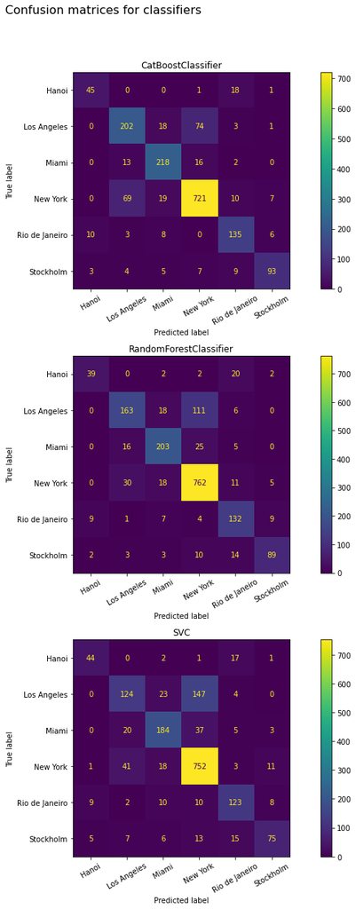

```python
fig = plot_confusion_matrices(best_classifiers, X_val, y_val, class_labels=le.classes_, figsize=(12, 18))
```

- All models confuses Hanoi mostly with Rio;
- RandomForest's and SVC's results in differentiating USA cities are interesting in their non-symmetry. In particular both of these models are nearly 4 times more likely to call Los Angeles New York than otherwise. Mistakes of Catboost are, in opposite, symmetric.

#### Feature Importances

```python
best_catboost_model = best_classifiers[0]
best_catboost_model.fit(X_train, y_train, eval_set=val_pool, verbose=50, early_stopping_rounds=100)
```

```
0:	learn: 1.7169001	test: 1.7194353	best: 1.7194353 (0)	total: 26.1ms	remaining: 26.1s
50:	learn: 0.7716042	test: 0.8688109	best: 0.8688109 (50)	total: 6.56s	remaining: 2m 2s
100:	learn: 0.5818696	test: 0.7267489	best: 0.7267489 (100)	total: 13s	remaining: 1m 55s
150:	learn: 0.4854029	test: 0.6731775	best: 0.6731775 (150)	total: 19.3s	remaining: 1m 48s
200:	learn: 0.4159125	test: 0.6442394	best: 0.6442394 (200)	total: 25.7s	remaining: 1m 42s
250:	learn: 0.3635131	test: 0.6264517	best: 0.6264517 (250)	total: 32.1s	remaining: 1m 35s
300:	learn: 0.3220476	test: 0.6098256	best: 0.6098256 (300)	total: 38.5s	remaining: 1m 29s
350:	learn: 0.2888506	test: 0.6023463	best: 0.6023463 (350)	total: 44.9s	remaining: 1m 23s
400:	learn: 0.2627939	test: 0.5925294	best: 0.5925294 (400)	total: 51.3s	remaining: 1m 16s
450:	learn: 0.2406704	test: 0.5872289	best: 0.5871954 (449)	total: 57.8s	remaining: 1m 10s
500:	learn: 0.2210143	test: 0.5822754	best: 0.5822754 (500)	total: 1m 4s	remaining: 1m 3s
550:	learn: 0.2041923	test: 0.5810721	best: 0.5810721 (550)	total: 1m 10s	remaining: 57.5s
600:	learn: 0.1895504	test: 0.5800534	best: 0.5798124 (598)	total: 1m 17s	remaining: 51.1s
650:	learn: 0.1771195	test: 0.5800553	best: 0.5798124 (598)	total: 1m 23s	remaining: 44.8s
700:	learn: 0.1662500	test: 0.5790708	best: 0.5790708 (700)	total: 1m 29s	remaining: 38.3s
750:	learn: 0.1562491	test: 0.5791513	best: 0.5783774 (711)	total: 1m 36s	remaining: 31.9s
800:	learn: 0.1471009	test: 0.5803411	best: 0.5783774 (711)	total: 1m 42s	remaining: 25.5s
Stopped by overfitting detector  (100 iterations wait)

bestTest = 0.5783773986
bestIteration = 711

Shrink model to first 712 iterations.
```

```
<catboost.core.CatBoostClassifier at 0x7f273bada190>
```

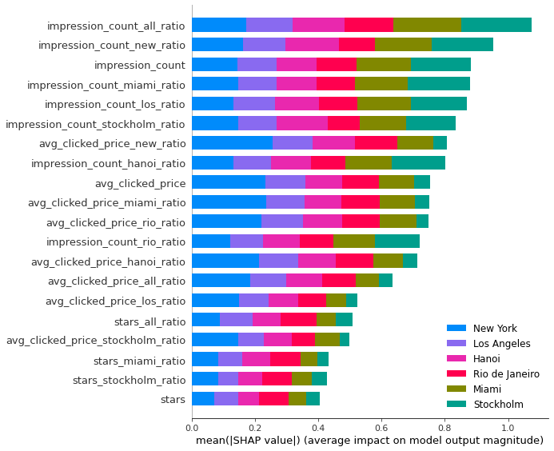

```python
explainer = shap.TreeExplainer(best_catboost_model)
shap_values = explainer.shap_values(X_train)

shap.summary_plot(shap_values, X_train, feature_names=hotel_agg_metrics.columns, class_names=le.classes_)
```

```python
def show_feature_importances(clf, columns):
    imps = np.array(clf.feature_importances_)
    sorted_features = [(x, col) for (x, col) in sorted(zip(imps, columns), key=lambda pair: pair[0])]
    return dict(sorted_features[::-1])
```

```python
show_feature_importances(best_catboost_model, hotel_agg_metrics.columns)
```

```
{3.061162009159771: 'impression_count',
 2.7889293857259694: 'impression_count_los_ratio',
 2.7642626377786144: 'impression_count_all_ratio',
 2.6632288195190426: 'stars_all_ratio',
 2.614443512748626: 'avg_clicked_price_new_ratio',
 2.4842534637709734: 'impression_count_miami_ratio',
 2.466935270222009: 'avg_clicked_price_rio_ratio',
 2.411043839963966: 'impression_count_new_ratio',
 2.326896046319674: 'avg_clicked_price_miami_ratio',
 2.3186136241615567: 'avg_clicked_price',
 2.2524118713726446: 'stars_los_ratio',
 2.201213509554985: 'impression_count_stockholm_ratio',
 2.005499850165104: 'avg_clicked_price_hanoi_ratio',
 1.9554971904381104: 'avg_clicked_price_all_ratio',
 1.9553543501248039: 'stars_new_ratio',
 1.9543557403848064: 'stars',
 1.9108930416704255: 'impression_count_hanoi_ratio',
 1.8796377719357853: 'avg_cpc',
 1.879492631704308: 'avg_cpc_miami_ratio',
 1.8409605365849402: 'hotel_rating_los_ratio',
 1.815931684896404: 'avg_cpc_hanoi_ratio',
 1.7916107003656068: 'hotel_rating_rio_ratio',
 1.7774415863354796: 'avg_cpc_all_ratio',
 1.7658070966564203: 'avg_cpc_los_ratio',
 1.7596252571063196: 'stars_stockholm_ratio',
 1.7475076840028347: 'stars_miami_ratio',
 1.7160165321239012: 'hotel_rating_miami_ratio',
 1.6622395829116061: 'stars_hanoi_ratio',
 1.6614881274987239: 'hotel_rating_stockholm_ratio',
 1.642917128229834: 'avg_clicked_price_los_ratio',
 1.6357795005300617: 'hotel_rating',
 1.623716424380714: 'avg_cpc_stockholm_ratio',
 1.6182504922145484: 'avg_cpc_rio_ratio',
 1.5940408627726095: 'impression_count_rio_ratio',
 1.5802648809113662: 'stars_rio_ratio',
 1.5563951365109632: 'hotel_rating_hanoi_ratio',
 1.5451605775997888: 'hotel_rating_new_ratio',
 1.5169955972731726: 'avg_clicked_price_stockholm_ratio',
 1.4180397850569235: 'avg_length_of_stay_stockholm_ratio',
 1.3904627202469355: 'avg_time_to_travel_rio_ratio',
```

[output cut: 17 more lines]

```
 0.4290911907959079: 'click_count_los_ratio',
 0.390775817484298: 'click_count_rio_ratio',
 0.39000050769812183: 'click_count_hanoi_ratio',
 0.38840397227803164: 'click_count_miami_ratio',
 0.30079134126425: 'click_count_all_ratio',
 0.2826813268877314: 'click_count',
 0.2611842056982637: 'click_count_new_ratio',
 0.08979373256180798: 'booking_count_miami_ratio',
 0.05629815242459687: 'booking_count_stockholm_ratio',
 0.04596400426790434: 'booking_count_los_ratio',
 0.04518022136787308: 'booking_count_hanoi_ratio',
 0.04442600724729762: 'booking_count_new_ratio',
 0.027128733373528877: 'booking_count',
 0.023585633967000013: 'booking_count_all_ratio',
 0.021964354167285: 'booking_count_rio_ratio'}
```

```python
best_tree_model = best_classifiers[1]
best_tree_model.fit(X_train, y_train)
show_feature_importances(best_tree_model, hotel_agg_metrics.columns)
```

```
{0.031560232282844713: 'impression_count_rio_ratio',
 0.028280603815061197: 'impression_count_los_ratio',
 0.025944580637204718: 'impression_count_hanoi_ratio',
 0.023999686495223608: 'impression_count_all_ratio',
 0.023336081381580567: 'avg_cpc_all_ratio',
 0.023096886109036475: 'avg_clicked_price_stockholm_ratio',
 0.02304664572751723: 'impression_count_new_ratio',
 0.022909233774441012: 'avg_clicked_price_hanoi_ratio',
 0.02255457228646293: 'impression_count_miami_ratio',
 0.022553786702948796: 'avg_cpc_stockholm_ratio',
 0.022448512363358764: 'avg_cpc',
 0.022300264057327466: 'avg_clicked_price_new_ratio',
 0.02201188652498919: 'avg_clicked_price_miami_ratio',
 0.02183813384478115: 'avg_cpc_rio_ratio',
 0.02156169939637075: 'impression_count',
 0.02145725447079215: 'avg_cpc_miami_ratio',
 0.021139199221840942: 'avg_cpc_new_ratio',
 0.020979468450447913: 'impression_count_stockholm_ratio',
 0.02074452995852613: 'avg_clicked_price_rio_ratio',
 0.02010745834242979: 'avg_clicked_price',
 0.020030007360310548: 'hotel_rating_new_ratio',
 0.01969775795976051: 'avg_cpc_los_ratio',
 0.019003005458195943: 'avg_clicked_price_los_ratio',
 0.018511575264230338: 'avg_cpc_hanoi_ratio',
 0.018485434038140066: 'hotel_rating_miami_ratio',
 0.018455475807679148: 'hotel_rating_rio_ratio',
 0.018401330324007863: 'hotel_rating_hanoi_ratio',
 0.0182356629387321: 'hotel_rating',
 0.017673986896693507: 'hotel_rating_stockholm_ratio',
 0.017333715871387247: 'avg_clicked_price_all_ratio',
 0.017323598322215597: 'hotel_rating_all_ratio',
 0.016879086575967435: 'hotel_rating_los_ratio',
 0.01308891634895863: 'stars_rio_ratio',
 0.01303230342388066: 'stars_all_ratio',
 0.013017846573248209: 'stars_hanoi_ratio',
 0.012706092790734496: 'stars_los_ratio',
 0.012259869838991487: 'avg_time_to_travel_stockholm_ratio',
 0.012030959689836338: 'stars_new_ratio',
 0.011551030657980804: 'click_count_stockholm_ratio',
 0.011539530892698532: 'stars',
```

[output cut: 17 more lines]

```
 0.006912302595531325: 'click_count_all_ratio',
 0.006773818694037665: 'click_count',
 0.006444182636473255: 'click_count_los_ratio',
 0.006181447543236073: 'click_count_miami_ratio',
 0.00483902417131458: 'click_count_new_ratio',
 0.004428114913718014: 'click_count_hanoi_ratio',
 0.0038298440321281723: 'click_count_rio_ratio',
 0.00041730364201851: 'booking_count_los_ratio',
 0.0003724968712428994: 'booking_count_all_ratio',
 0.00032746404212188396: 'booking_count_hanoi_ratio',
 0.00030250298932723945: 'booking_count',
 0.00025555695807954223: 'booking_count_new_ratio',
 0.00025216093729631714: 'booking_count_rio_ratio',
 0.00025128762224815474: 'booking_count_miami_ratio',
 0.00024554621870884424: 'booking_count_stockholm_ratio'}
```

At first, great that our generated ratio features worked so good :)

Based on models' estimates of features importances and shap scores, we could be able to lower the feature space. For example, it seems like features connected with booking count and clicks count are almost useless. By iteratively refitting the model to a subset of the best features we might achieve the same or better (if unimportant features only add noise) quality using less data and save on storage.

### Predict for test

```python
test_pool = Pool(X_final_test[hotel_agg_metrics.columns])

catboost_preds = le.inverse_transform(best_catboost_model.predict(test_pool).ravel())
forest_preds = le.inverse_transform(best_tree_model.predict(X_final_test[hotel_agg_metrics.columns].values))
```

```python
X_final_test['predicted_city_catboost'] = catboost_preds
X_final_test['predicted_city_forest'] = forest_preds
```

```python
Counter(forest_preds), Counter(catboost_preds)
```

```
(Counter({'New York': 1116}), Counter({'Miami': 50, 'New York': 1066}))
```

```python
answer = X_final_test[['hotel_id', 'predicted_city_catboost']].groupby('hotel_id', as_index=False).agg(lambda x: pd.Series.mode(x))
answer['predicted_city_catboost'].value_counts()
```

[output not shown]

:-/

In some cases when catboost predicted `Miami` class, it was for the same hotel_id as it predicted `New York` equal or more number of times.

Here we show this

```python
mode_answer = X_final_test[['hotel_id', 'predicted_city_catboost']].groupby('hotel_id', as_index=False).agg(lambda x: pd.Series.mode(x))
mode_answer['predicted_city_catboost'].value_counts()
```

```
New York             149
Miami                  9
[Miami, New York]      1
[Miami, New York]      1
[Miami, New York]      1
[Miami, New York]      1
Name: predicted_city_catboost, dtype: int64
```

*"Some folks like to get away, take a holiday from the neighbourhood. Hop a flight to Miami Beach or to Hollywood. But I'm taking a Greyhound on the Hudson River Line. I'm in a New York state of mind..." ([Billy Joel](https://www.youtube.com/watch?v=iM4LzEcaTK0))* </font>

### (Optional) Save model and statistics

**Save CatBoost model**

```python
! mkdir model_files
```

```python
MODEL_FOLDER = 'model_files'

catboost_path = os.path.join(MODEL_FOLDER, 'catboost-17-5-2022.cbm')
best_catboost_model.save_model(fname=catboost_path, pool=train_pool)
```

Check that we can load it and use on test data

```python
reloaded_catboost_model = CatBoostClassifier()

reloaded_catboost_model.load_model(catboost_path)
```

```
<catboost.core.CatBoostClassifier at 0x7f27b5ea9670>
```

```python
reloaded_catboost_model.get_params()
```

```
{'od_wait': 100,
 'od_type': 'Iter',
 'verbose': 50,
 'iterations': 1000,
 'thread_count': 12,
 'auto_class_weights': 'Balanced',
 'loss_function': 'MultiClass',
 'depth': 9,
 'random_seed': 1337,
 'learning_rate': 0.05}
```

```python
reloaded_preds = reloaded_catboost_model.predict(test_pool).ravel()
best_preds = best_catboost_model.predict(test_pool).ravel()

assert np.allclose(reloaded_preds, best_preds)
```

**Save statistics for data processing**

Mean metrics values across all cities

```python
data_agg_metrics.index.name = 'metric'
data_agg_metrics.to_csv(os.path.join(MODEL_FOLDER, 'general_aggregations.csv'))
```

```python
reloaded_data_agg = pd.read_csv(os.path.join(MODEL_FOLDER, 'general_aggregations.csv'), index_col='metric')
reloaded_data_agg
```

| metric | 0 |
| --- | --- |
| impression_count | 746.330191 |
| click_count | 12.438633 |
| booking_count | 0.125291 |
| avg_cpc | 1.141626 |
| avg_clicked_price | 169.163715 |
| avg_length_of_stay | 2.715997 |
| avg_time_to_travel | 40.816692 |
| hotel_rating | 80.246568 |
| stars | 2.860762 |

Mean metrics values by city

```python
city_agg_metrics.to_csv(os.path.join(MODEL_FOLDER, 'city_aggregations.csv'), index=False)
```

```python
reloaded_city_agg = pd.read_csv(os.path.join(MODEL_FOLDER, 'city_aggregations.csv'))
reloaded_city_agg
```

|  | city | impression_count | click_count | booking_count | avg_cpc | avg_clicked_price | avg_length_of_stay | avg_time_to_travel | hotel_rating | stars |
| --- | --- | --- | --- | --- | --- | --- | --- | --- | --- | --- |
| 0 | Hanoi | 11.104730 | 1.533784 | 0.010135 | 0.640912 | 71.052309 | 2.170804 | 37.437500 | 85.032464 | 3.381757 |
| 1 | Los Angeles | 580.836528 | 11.252778 | 0.136806 | 1.052812 | 154.120260 | 2.262685 | 27.145208 | 75.460372 | 2.246528 |
| 2 | Miami | 596.205401 | 12.119476 | 0.156301 | 0.946718 | 117.986825 | 2.729741 | 45.022300 | 78.952845 | 2.679214 |
| 3 | New York | 1131.856925 | 17.011773 | 0.149753 | 1.285757 | 214.978266 | 2.573072 | 39.415357 | 81.601287 | 3.003296 |
| 4 | Rio de Janeiro | 38.556750 | 2.583035 | 0.028674 | 0.777814 | 94.663983 | 4.355969 | 69.839200 | 80.962494 | 3.175627 |
| 5 | Stockholm | 24.736655 | 2.033808 | 0.048043 | 1.509359 | 135.397861 | 2.772391 | 35.847936 | 81.498716 | 3.008897 |

Mean rating based on number of stars

```python
stars_ratings.to_csv(os.path.join(MODEL_FOLDER, 'stars_to_rating.csv'))
```

```python
reloaded_stars_ratings = pd.read_csv(os.path.join(MODEL_FOLDER, 'stars_to_rating.csv'), index_col='stars')
reloaded_stars_ratings
```

| stars | count | min | max | median | mean |
| --- | --- | --- | --- | --- | --- |
| 0 | 233 | 46.07 | 96.11 | 80.840 | 79.548155 |
| 1 | 18 | 37.99 | 87.63 | 65.220 | 65.933889 |
| 2 | 181 | 44.88 | 94.39 | 73.460 | 73.072983 |
| 3 | 450 | 50.30 | 96.10 | 81.305 | 80.255622 |
| 4 | 394 | 55.74 | 95.61 | 83.420 | 82.826066 |
| 5 | 104 | 69.81 | 95.04 | 87.635 | 87.303942 |

```python
stars2missing_rating = stars_ratings['mean'].to_dict()
stars2missing_rating
```

```
{0: 79.54815450643777,
 1: 65.93388888888889,
 2: 73.07298342541436,
 3: 80.25562222222221,
 4: 82.82606598984772,
 5: 87.30394230769231}
```

### (Optional) Organize preprocessing into functions

early draft for organizing preprocessing in a python file

```python
%%writefile preprocess.py

from typing import Optional

import numpy as np
import pandas as pd
from sklearn.preprocessing import scale


METRICS_COLS = ['impression_count', 'click_count', 'booking_count', 'avg_cpc', 'avg_clicked_price', 'avg_length_of_stay', 'avg_time_to_travel']
FEATURES_COLS = METRICS_COLS + ['stars', 'hotel_rating']

def clip_outliers(feature: pd.Series, lower_perc: int=1, upper_perc: int=98) -> np.ndarray:
    lower_bound, upper_bound = np.percentile(feature.values, [lower_perc, upper_perc])
    return np.clip(feature, lower_bound, upper_bound)

def fill_missing_rating(hotel_details: pd.DataFrame, stars2rating: Optional[dict] = None, special_char: str = '\\N') -> pd.DataFrame:
    if stars2rating is None:
        stars_ratings = hotel_details[hotel_details['hotel_rating'] >= 0].groupby(by=['stars'], as_index=False)['hotel_rating'].mean().to_frame()
        stars2rating = stars_ratings['mean'].to_dict()

    df_corrected = hotel_details.replace(special_char, -10)
    df_corrected['hotel_rating'] = df_corrected['hotel_rating'].astype('float')
    df_corrected.loc[df_corrected['hotel_rating'] < 0, ['hotel_rating']] = df_corrected[df_corrected['hotel_rating'] < 0]['stars'].apply(lambda star: stars2rating[star])

    return df_corrected

def create_features_df(
    hotel_metrics: pd.DataFrame,
    hotel_details: pd.DataFrame,
    feature_agg_columns: list,
    data_agg_metrics: Optional[pd.DataFrame] = None,
    city_agg_metrics: Optional[pd.DataFrame] = None,
    missing_city_kw: str = 'unknown',
) -> pd.DataFrame:

    united_hotel_metrics = pd.merge(hotel_metrics, hotel_details, how='left', on='hotel_id')
    united_hotel_metrics.drop(columns=['date_ymd', 'country'], inplace=True)

    if data_agg_metrics is None:
        data_agg_metrics = united_hotel_metrics[united_hotel_metrics['city'] != missing_city_kw][feature_agg_columns].mean().to_frame()

    if city_agg_metrics is None:
        city_agg_metrics = united_hotel_metrics[united_hotel_metrics['city'] != missing_city_kw].groupby(by=['city'], as_index=False)[feature_agg_columns].mean()

    cities = city_agg_metrics['city'].values

    for feature in feature_agg_columns:
        united_hotel_metrics[f'{feature}_all_ratio'] = united_hotel_metrics[feature] / data_agg_metrics.loc[feature].values[0]
        for city in cities:
            united_hotel_metrics[f'{feature}_{city.split()[0].lower()}_ratio'] = united_hotel_metrics[feature] / city_agg_metrics.loc[city_agg_metrics['city'] == city][feature].values[0]

    united_hotel_metrics.drop(columns=['hotel_id', 'city'], inplace=True)
    return united_hotel_metrics

def run_preprocess_pipeline(
    hotel_metrics: pd.DataFrame,
    hotel_details: pd.DataFrame,
    data_agg_metrics: Optional[pd.DataFrame] = None,
    city_agg_metrics: Optional[pd.DataFrame] = None,
    stars2missing_rating: Optional[dict] = None
) -> np.array:

    for col in METRICS_COLS:
        hotel_metrics[col] = clip_outliers(hotel_metrics[col])

    hotel_details = fill_missing_rating(hotel_details, stars2missing_rating)

    new_features = create_features_df(hotel_metrics, hotel_details, FEATURES_COLS, data_agg_metrics, city_agg_metrics)

    return scale(new_features)

def run_preprocess_pipeline_with_paths(
    hotel_metrics_path: str,
    hotel_details_path: str,
    data_agg_metrics_path: Optional[str] = None,
    city_agg_metrics_path: Optional[str] = None,
    stars2rating_path: Optional[str] = None
) -> np.array:
    '''
    Return features for CatBoost model inference given hotel metrics and pre-calculated statistics.
    If the paths to statistics are not provided, they will be recalculated on provided hotel data.
    '''

    hotel_details = pd.read_csv(hotel_details_path)
    hotel_metrics = pd.read_csv(hotel_metrics_path, parse_dates=['date_ymd'])

    reloaded_city_agg = pd.read_csv(city_agg_metrics_path)
    reloaded_data_agg = pd.read_csv(data_agg_metrics_path, index_col='metric')

    reloaded_stars_ratings = pd.read_csv(stars2rating_path, index_col='stars')
    stars2missing_rating = reloaded_stars_ratings['mean'].to_dict()

    return run_preprocess_pipeline(hotel_metrics, hotel_details, reloaded_data_agg, reloaded_city_agg, stars2missing_rating)
```

```
Overwriting preprocess.py
```

```python
from preprocess import run_preprocess_pipeline_with_paths
```

```python
run_preprocess_pipeline_with_paths(
    'data/hotel_metrics.csv',
    'data/hotel_details.csv',
    'model_files/general_aggregations.csv',
    'model_files/city_aggregations.csv',
    'model_files/stars_to_rating.csv',
)
```

```
array([[ 0.88796777,  0.21054677, -0.31350317, ..., -0.72381975,
        -0.72381975, -0.72381975],
       [ 0.14804789,  0.8443567 , -0.31350317, ..., -0.72381975,
        -0.72381975, -0.72381975],
       [ 0.38704201,  0.8443567 ,  2.14792721, ..., -0.72381975,
        -0.72381975, -0.72381975],
       ...,
       [ 0.22056004, -0.07754865, -0.31350317, ..., -4.01400033,
        -4.01400033, -4.01400033],
       [-0.06800872, -0.19278682, -0.31350317, ..., -4.01400033,
        -4.01400033, -4.01400033],
       [-0.24484957, -0.07754865, -0.31350317, ..., -4.01400033,
        -4.01400033, -4.01400033]])
```

## Python Workflow

Now that you have the model from Task 3, let’s imagine the situation where the model was accepted and we want to put it into production. For that, we need to build a Python/PySpark workflow.

I guess, general pipeline should be the following.

Initial steps, after we decided to keep the model and prepare it to run in production:

1. Research, train different models on a large train set, find the best and fine-tune parameters;
2. Create stable test dataset. It will be used for evalution of future changes to our model;
3. Save best candidate's model parameters to some storage. It might be a simple solution like having a folder with model weights named in a way `model_[creationDate]`. Or we could use something like MLFlow to organize better. Or smth in the middle like noSQL database with dictionary files (e.g. Mongo);
4. Save data needed for preprocessing. In my case I should save statistics that I use for features generations. It might be a good idea to revisit them from time to time and create newer versions of the model (if it outperforms the initial one on the test set, of course).

More implementation-specific steps:

1. The main script should:
   - start on schedule (like on cron) or when called,
   - load the new data from the upward stream (e.g. read from a database),
   - load the model with best tuned parameters,
   - call preprocessor for the new data, generate necessary features as were in the training procedure,
   - make prediction,
   - write data to the same stream (e.g. write to SQL database)
2. There sould be some mechanic to enable automatic model retraining. For example, once in a few weeks, we run the pipeline with the only change in train data (newer). It might help to better adapt the model to current circumstances.